# Problem Set 7

Clinton Tepper

## Problem 1

Consistent with the previous problem set, we will define $V_{i}\equiv\beta_{p}ln\left(P\right)$. We write the likelihood function as:

$$\begin{align*}
L\left(\beta_{p}\right)= & \prod_{i=1}^{N}\left(Pr\left(X_{i}=k\right)\right)\\
L\left(\beta_{p}\right)= & \prod_{i=1}^{N}\begin{cases}
\frac{1}{1+exp\left(\beta_{p}ln\left(P\right)\right)} & X_{i}=0\\
\left(\frac{exp\left(\beta_{p}ln\left(P\right)\right)}{1+exp\left(\beta_{p}ln\left(P\right)\right)}\right) & X_{i}=1
\end{cases}
\end{align*}$$

Taking the log:

$$\begin{align*}
l\left(\beta_{p}\right)= & \sum_{i=1}^{N}\begin{cases}
-ln\left(1+exp\left(\beta_{p}ln\left(P\right)\right)\right) & X_{i}=0\\
\beta_{p}ln\left(P\right)-ln\left(1+exp\left(\beta_{p}ln\left(P\right)\right)\right) & X_{i}=1
\end{cases}
\end{align*}$$

Or equivelently (defining $\eta$to be the number of times $X_{i}=1$):

$$\begin{align*}
l\left(\beta_{p}\right)= & \eta\beta_{p}ln\left(P\right)-Nln\left(1+exp\left(\beta_{p}ln\left(P\right)\right)\right)
\end{align*}$$

If we are sampling K prices:

$$\begin{align*}
l\left(\beta_{p}\right)= & \sum_{j=1}^{K}\left[\eta_{k}\beta_{p}ln\left(P_{k}\right)-Nln\left(1+exp\left(\beta_{p}ln\left(P_{k}\right)\right)\right)\right]
\end{align*}$$

We can increase the sensitivity of this equation to price by increasing beta. With a positive log-price, the log-likelihood contribution for $X_{i}=0$ will be strongly negative to reflect the low probability of this event, while the reverse is true for a negative log-price. Empirically, we will choose a beta of 500 to exemplify this discrepancy. Defining $\eta$ and writing out the FOC:

$$\begin{align*}
\frac{\partial l}{\partial\beta_{p}}=0= & \sum_{j=1}^{K}\left[\eta_{k}ln\left(P_{k}\right)-\frac{Nln\left(P_{k}\right)exp\left(\beta_{p}ln\left(P_{k}\right)\right)}{1+exp\left(\beta_{p}ln\left(P_{k}\right)\right)}\right]\\
\frac{\partial l}{\partial\beta_{p}}=0= & \sum_{j=1}^{K}\left[\frac{ln\left(P_{k}\right)\left(\eta_{k}-\left(N-\eta_{k}\right)exp\left(\beta_{p}ln\left(P_{k}\right)\right)\right)}{1+exp\left(\beta_{p}ln\left(P_{k}\right)\right)}\right]
\end{align*}$$

With a high enough $\beta$, we will either get $\eta=N$ or $\eta=0$. Therefore:

$$\begin{align*}
\frac{\partial l}{\partial\beta_{p}}=0= & \sum_{j=1}^{K}\left[\begin{cases}
-\frac{Nln\left(P_{k}\right)exp\left(\beta_{p}ln\left(P_{k}\right)\right)}{1+exp\left(\beta_{p}ln\left(P_{k}\right)\right)} & \eta_{k}=0\\
\frac{Nln\left(P_{k}\right)}{1+exp\left(\beta_{p}ln\left(P_{k}\right)\right)} & \eta_{k}=N
\end{cases}\right]
\end{align*}$$

Trying to solve for the MLE:

$$\begin{align*}
0= & \sum_{j=1}^{K}\left[\begin{cases}
-exp\left(\beta_{p}ln\left(P_{k}\right)\right) & \eta_{k}=0\\
1 & \eta_{k}=N
\end{cases}\right]
\end{align*}$$

Let $K_{0}$ be the number of prices where $\eta=0$ and $K_{N}$ be the number of times $\eta=N$. Then:

$$\begin{align*}
\sum_{j=1}^{K}\left[\begin{cases}
-exp\left(\beta_{p}ln\left(P_{k}\right)\right) & \eta_{k}=0\\
0 & \eta_{k}=N
\end{cases}\right]= & K_{N}
\end{align*}$$

This equation clearly has no (real) solution.

The following code demonstrates the above result empirically:

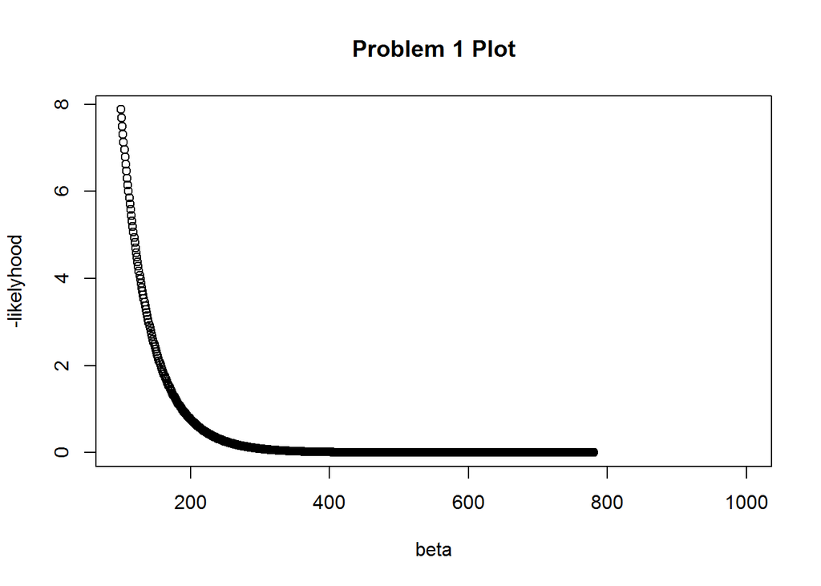

```r
set.seed(11);
#allows for reproducibility

#The likelihood function for a multinomial distribution
#In: A set of parameters and a data set
#Out: The sum of the log likelihoods for each data point
logitLogLike = function(V, cMat) {
    minLike = -10 ^ 9;
    maxLike = 10 ^ 9;
    denom = matrix(apply(V, 2, function(x) log(sum(exp(x)))), nrow = 1);
    #calculate the denominator for each price
    #calculate the log probability for each value of v
    logPVec = t(apply(V, 1, function(x) x - denom));

    #The below command looks up the logged probability for each entry in cMat and sums the total
    return(sum(sapply(1:ncol(V), function(x) sum(logPVec[cMat[, x], x]))));
}

#A wrapper function for logitLike amenable to the setup in problem 6
# Note that a null alternative is added. The null alternative is assumed to be J=1.
#In: Alpha, Beta, and the  data set
#Out: The sum of the log likelihoods for each data point
multinomChoiceModelLike = function(alpha, beta, lPrice, cMat) {

    #form the matrix of Vs
    return(logitLogLike(apply(lPrice, 2, function(x) alpha + beta * x), cMat));
}

#A gradient function specific to problem 1
# Note that a null alternative is added. The null alternative is assumed to be J=1.
#In: Alpha, Beta, price, and the  data set. Alpha[0] and price[0] are assumed to be zero.
#Out: The gradient of the likelihood
multinomChoiceModelGrad = function(alpha, beta, lPrice, cMat) {
    L = nrow(cMat);
    W = ncol(cMat);
    J = length(alpha);
    eta = matrix(sapply(1:J,
        function(x) apply(cMat, 2, function(y) sum(y == x))), nrow = J, ncol = W, byrow = TRUE);
        #calculate the denominator for each price series
    denom = apply(lPrice, 2, function(x) sum(exp(alpha + x * beta)));
    #the below return calculates and sums the gradients accross prices

    return(rbind(matrix(sapply(2:J,
        function(x) sum(eta[x,] - L * exp(alpha[x] + beta * lPrice[x,]) / denom)), ncol = 1),
        sum(sapply(1:J,
            function(x) sum(lPrice[x,] * (eta[x,] - L * exp(alpha[x] + beta * lPrice[x,]) / denom))))));
            }

##########################Problem 1 Entry Point##########################

#Define the Parameters
numSamples = 50;
numPriceVectrs = 20;
alpha = matrix(NA, 2);
alpha[1] = 0;
alpha[2] = 0;
beta = 500;
lowerBound = 0.1;
upperBound = 5000;
maxIter = 100;

numPrices = length(alpha);
#get the prices
logPrices = rbind(matrix(rep(0, numPriceVectrs), nrow = 1),
    matrix(runif(numPriceVectrs * (numPrices - 1), -1, 1), nrow = numPrices - 1));

#Simulate the data
unifPts = 0
iter = 0
while ((unifPts != numSamples * numPriceVectrs) && (iter < maxIter)) {
    popPVec = exp(rep(alpha, numPriceVectrs) + logPrices * beta);
    popPVec = apply(popPVec, 2, function(x) x / sum(x));
    sampMat = matrix(sapply(1:numPriceVectrs,
        function(x) sample.int(numPrices, numSamples, replace = TRUE, popPVec[, x])),
        nrow = numSamples, ncol = numPriceVectrs);
    unifPts = sum(sapply(1:numPriceVectrs, function(x) sum(sampMat[1, x] == sampMat[, x])));
    iter = iter + 1;
}
#print(sampMat);
if (iter == maxIter) print("Warning: Conformed data set not generated");
#Get the maximum likelihood of the parameters
likeFunc = function(b)
    - multinomChoiceModelLike(alpha, b, logPrices, sampMat);

gradFunc = function(b)
    - multinomChoiceModelGrad(alpha, b, logPrices, sampMat)[numPrices];

gMin = 100;
gMax = 1000;
xVec = gMin:gMax;
yVec = sapply(gMin:gMax, likeFunc)


plot(xVec, yVec, main = "Problem 1 Plot", xlab = "beta", ylab = "-likelyhood");
```

```r
out = optim(700, likeFunc, gradFunc,
    method = "L-BFGS-B",
    lower = c(rep(lowerBound, numPrices)),
    upper = c(rep(upperBound, numPrices)));

print(out);
```

```
## $par
## [1] 700
##
## $value
## [1] 1.774026e-05
##
## $counts
## function gradient
##        2        2
##
## $convergence
## [1] 0
##
## $message
## [1] "CONVERGENCE: REL_REDUCTION_OF_F <= FACTR*EPSMCH"
```

## Problem 2

### Likelihood Ratio Test

We redefine $V_{i}$ as $V_{i}\equiv\alpha_{1}+\sum_{k=2}^{K}x_{k}\beta_{k}$. The likelihood function then becomes:

$$\begin{align*}
L\left(\alpha,\beta\right)= & \prod_{i=1}^{N}\left(Pr\left(Y_{i}=1\right)\right)\\
L\left(\alpha,\beta\right)= & \prod_{i=1}^{N}\begin{cases}
\frac{1}{1+exp\left(\alpha_{1}+\sum_{k=2}^{K}x_{ik}\beta_{k}\right)} & Y_{i}=0\\
\left(\frac{exp\left(\alpha_{1}+\sum_{k=2}^{K}x_{ik}\beta_{k}\right)}{1+exp\left(\alpha_{1}+\sum_{k=2}^{K}x_{ik}\beta_{k}\right)}\right) & Y_{i}=1
\end{cases}
\end{align*}$$

Taking the log-likelihood:

$$\begin{align*}
l\left(\alpha,\beta\right)= & \sum_{i=1}^{N}\left(\alpha_{1}+\sum_{k=2}^{K}x_{ik}\beta_{k}\right)Y_{i}-\sum_{i=1}^{N}ln\left(1+exp\left(\alpha_{1}+\sum_{k=2}^{K}x_{ik}\beta_{k}\right)\right)
\end{align*}$$

The gradient vector becomes:

$$\begin{align*}
\frac{\partial l}{\partial\alpha_{1}}= & \sum_{i=1}^{N}\left(Y_{i}\right)-\sum_{i=1}^{N}\frac{exp\left(\alpha_{1}+\sum_{k=2}^{K}x_{ik}\beta_{k}\right)}{1+exp\left(\alpha_{1}+\sum_{k=2}^{K}x_{ik}\beta_{k}\right)}\\
\frac{\partial l}{\partial\beta_{k}}= & \sum_{i=1}^{N}\left(x_{ik}Y_{i}\right)-\sum_{i=1}^{N}\frac{x_{ik}exp\left(\alpha_{1}+\sum_{k=2}^{K}x_{ik}\beta_{k}\right)}{1+exp\left(\alpha_{1}+\sum_{k=2}^{K}x_{ik}\beta_{k}\right)}
\end{align*}$$

Under the null hypothesis, the MLE becomes (denoting the number of successes as $\eta$):

$$\begin{align*}
\frac{\partial l}{\partial\alpha_{1}}= & \eta-\sum_{i=1}^{N}\frac{exp\left(\alpha_{1}\right)}{1+exp\left(\alpha_{1}\right)}=0\\
\eta & =\left(N-\eta\right)exp\left(\alpha_{1}\right)\\
\alpha_{1}= & ln\left(\frac{\eta}{N-\eta}\right)
\end{align*}$$

The likelihood ratio rest statistic is defined as:

$$\begin{align*}
\lambda= & 2\left(ln\left(MLE\right)-\sum_{i=1}^{N}\left(ln\left(\frac{\eta}{N-\eta}\right)\right)X_{i}-\sum_{i=1}^{N}ln\left(1+exp\left(ln\left(\frac{\eta}{N-\eta}\right)\right)\right)\right)\\
\lambda= & 2\left(ln\left(MLE\right)-\sum_{i=1}^{N}\left(ln\left(\frac{\eta}{N-\eta}\right)\right)X_{i}-\sum_{i=1}^{N}ln\left(\frac{N}{N-\eta}\right)\right)\\
\lambda= & 2\left(ln\left(MLE\right)-\eta ln\left(\frac{\eta}{N-\eta}\right)-Nln\left(\frac{N}{N-\eta}\right)\right)
\end{align*}$$

The null hypothesis represents the scenario where none of the independent variables $x_{i}$ influence the distribution, with the distribution entirely specified by parameter $\alpha_{1}$. Specifically, the null hypothesis will denote the scenario where all $\beta$ terms equal zero.

### Wald Test

In this scenario:

$$\begin{align*}
r(\theta)= & \begin{bmatrix}\hat{\beta_{2}}\\
\vdots\\
\beta_{K}
\end{bmatrix}\\
R_{\left(K-1\right)x\left(K-1\right)}= & \begin{bmatrix}1 & 0 & \cdots & 0\\
0 & \ddots & 0 & \vdots\\
\vdots & 0 & \ddots & 0\\
0 & \cdots & 0 & 1
\end{bmatrix}\\
I^{-1}= & \left[\frac{\partial l\beta}{\partial\theta_{i}\partial\theta_{j}}\right]^{-1}\\
T\left(\hat{\theta}\right)= & r^{t}\left(RVarR^{t}\right)^{-1}r=r^{t}I^{-1}r\sim\chi_{K-1}^{2}
\end{align*}$$

### Simulation

We use the following true value for beta to simulate $10^{5}$ data points:

$$\begin{align*}
\beta=\begin{bmatrix}\alpha_{1}\\
\beta_{2}\\
\beta_{3}\\
\beta_{4}\\
\beta_{5}
\end{bmatrix}= & \begin{bmatrix}0.5\\
1\\
1.5\\
2\\
2.5
\end{bmatrix}
\end{align*}$$

We see from the below results that we reject the null hypothesis at any reasonable signficance level.

```r
#The likelihood function for a multinomial distribution
#In: A set of parameters and a data set
#Out: The sum of the binary likelihoods for each data point
binLogLike = function(beta, xMat, yVec) {
    expon = xMat %*% beta;
    #calculate the exponent

    return(t(yVec) %*% expon - sum(log(1 + exp(expon))));
}

#A gradient function specific to problem 7
#In: beta coeficients, matrix of xvalues, y values. The first beta value is assumed to be the intercept
#Out: The gradient of the likelihood
binLogGrad = function(beta, xMat, yVec) {
    DoF = length(beta);
    expon = xMat %*% beta;

    return(rbind(sum(yVec) - sum(exp(expon) / (1 + exp(expon))),
        matrix(sapply(2:DoF,
            function(k) t(xMat[, k]) %*% (yVec - (exp(expon) / (1 + exp(expon))))),
        nrow = dof - 1)));
}

##########################Problem 2 Entry Point##########################

#Define the Parameters
numSamples = 10 ^ 5;
beta = matrix(seq(0.5, 2.5, .5), nrow = 5);
#beta = matrix(c(.38, 0, 0, 0, 0), nrow = 5);
initBeta = matrix(rep(rep(1, 5), nrow = 5));
dof = length(beta);
lowerBound = -1;
upperBound = 5;

#Simulate the x values
xMat = cbind(rep(1, numSamples),
    matrix(runif((dof - 1) * numSamples, -1, 1), nrow = numSamples, ncol = dof - 1));

#simulate the y values
yVec = runif(numSamples);
expon = xMat %*% beta;
yVec = (yVec < exp(expon) / (1 + exp(expon)));

#Get the maximum likelihood of the parameters
likeFunc = function(b) - binLogLike(b, xMat, yVec);
gradFunc = function(b) - binLogGrad(b, xMat, yVec);

#get the mle data
out = optim(initBeta, likeFunc, gradFunc,
    method = "L-BFGS-B",
    lower = c(rep(lowerBound, dof)),
    upper = c(rep(upperBound, dof)),
    hessian = TRUE);

print(out);
```

```
## $par
##           [,1]
## [1,] 0.4827311
## [2,] 1.0175316
## [3,] 1.4775923
## [4,] 1.9995670
## [5,] 2.5298078
##
## $value
## [1] 43260.73
##
## $counts
## function gradient
##       11       11
##
## $convergence
## [1] 0
##
## $message
## [1] "CONVERGENCE: REL_REDUCTION_OF_F <= FACTR*EPSMCH"
##
## $hessian
##            [,1]      [,2]      [,3]       [,4]       [,5]
## [1,] 14014.2656 -273.0823 -411.8050  -573.6401  -953.5734
## [2,]  -273.0823 4605.9272 -296.7922  -413.4180  -638.8107
## [3,]  -411.8050 -296.7922 4499.4238  -669.9921  -954.3554
## [4,]  -573.6401 -413.4180 -669.9921  4310.3928 -1372.3933
## [5,]  -953.5734 -638.8107 -954.3554 -1372.3933  3999.8541
```

```r
mlePar = matrix(out$par, nrow = dof);
mleVal = out$value;
mleHess = out$hessian[1:dof, 1:dof];
nullH = rbind(sum(yVec) / (sum(yVec) + numSamples), matrix(rep(0, dof - 1), nrow = dof - 1));
lambda = 2 * ( - mleVal + likeFunc(nullH));
print("Likelihood Ratio Test");
```

```
## [1] "Likelihood Ratio Test"
```

```r
print(1 - pchisq(lambda, dof - 1));
```

```
##      [,1]
## [1,]    0
```

```r
rVec = mlePar[2:dof] - nullH[2:dof];
W = t(rVec) %*% mleHess[2:dof, 2:dof] %*% rVec;
print("Wald Test");
```

```
## [1] "Wald Test"
```

```r
print(1 - pchisq(W, dof - 1));
```

```
##      [,1]
## [1,]    0
```

Therefore each test provides evidence for rejecting the null hypothesis.

## Problem 3

We want to show that:

$$\begin{align*}
P\left(\left|X_{n}-1\right|<\epsilon\right)\to & 0\\
P\left(\left|\frac{W^{2}}{\lambda}-1\right|<\epsilon\right)\to & 0
\end{align*}$$

First note:

$$\begin{align*}
W^{2}= & \left(\frac{\hat{\theta}-\theta_{0}}{SE}\right)^{2}=\left(\frac{\hat{\theta}-\theta_{0}}{s/\sqrt{n}}\right)^{2}\\
\lambda= & 2l\left(\hat{\theta}\right)-2l(\theta_{0})\\
s.t.\\
\hat{\theta}= & argmax\left[l(\theta)\right]
\end{align*}$$

Based on the problem hint, we expand $l\left(\hat{\theta}\right)$ to two terms:

$$\begin{align*}
l\left(\theta\right)\approx & l\left(\hat{\theta}\right)+l'\left(\hat{\theta}\right)\left(\theta_{0}-\hat{\theta}\right)+\frac{1}{2}l"\left(\theta\right)\left(\theta_{0}-\hat{\theta}\right)^{2}
\end{align*}$$

From the FOC’s, we know $l'(\hat{\theta)=0}$. Therefore:

$$\begin{align*}
l\left(\theta\right)\approx & l\left(\hat{\theta}\right)+\frac{1}{2}l"\left(\hat{\theta}\right)\left(\theta-\hat{\theta}\right)^{2}
\end{align*}$$

Therefore $\lambda$ becomes:

$$\begin{align*}
\lambda\approx & -l"\left(\hat{\theta}\right)\left(\theta_{0}-\hat{\theta}\right)^{2}
\end{align*}$$

Our statistic of concern therefore becomes:

$$\begin{align*}
X_{n}\approx & \frac{\left(\hat{\theta}-\theta_{0}\right)^{2}}{-l"\left(\hat{\theta}\right)\left(\theta_{0}-\hat{\theta}\right)^{2}}\\
X_{n}\approx & \frac{1}{-l"\left(\hat{\theta}\right)SE^{2}}
\end{align*}$$

Note however (from deck 7, slide 29):

$$\begin{align*}
SE\approx & \frac{1}{-l"\left(\hat{\theta}\right)}
\end{align*}$$

Therefore the sequence becomes:

$$\begin{align*}
X_{n}= & \frac{SE^{2}}{SE^{2}}=1\checkmark
\end{align*}$$